# HELPmiss (Data Verbs) Activity

Daniel Gao

## Set Up:

```r
rm(list = ls())     # clean up your R environment

# load packages
library(tidyverse)  # includes lots of data verbs like `group_by()` and `summarise()`
library(mosaicData) # includes the `HELPmiss` data set


# Load the `HELPmiss` data set into our RStudio environment
data("HELPmiss", package = "mosaicData")
```

## Helpful links:

- Look though the DC Textbook for `tidyverse` functions.
- Check out some of these RStudio cheat sheets:
  - https://www.rstudio.com/wp-content/uploads/2015/02/data-wrangling-cheatsheet.pdf
  - https://www.rstudio.com/resources/cheatsheets/
  - https://s3.amazonaws.com/assets.datacamp.com/blog_assets/Tidyverse+Cheat+Sheet.pdf

## Task 1: Data Description

*Write several sentences (or a bullet list) describing the HELP Study and the resulting `HELPmiss` data. Your description should investigate basic data provenance (e.g., Who, What, When, Where, Why, How), explain the setting for the data, specify what each case represents in the data, and remark on inclusion/exclusion criteria.*

- investigate by searching R help documentation
- there’s a research paper cited where additional detail is provided

??Helpmiss

**Who**: Adults inpatients recruited from a detoxification unit. Included in the experiment. The requirements for these adults were: who spoke Spanish or English, reported alcohol, heroin, or cocaine, as their first or second drug of choice, resided in proximity to the primary care clinic to which they would be referred or were homeless.

Excluded from the experiment. Patients with established primary care relationships they planned to continue, significant dementia, specific plans to leave the Boston area that would prevent research participation, failure to provide contact information for tracking purposes, or pregnancy were excluded.

**What**: Studied patients with no primary care physician

**When**: Patients were interviewed every 6 months for 2 years

**Where**: At a clinic

**Why**: The goal was to link these patients to primary care

**How**: Each patients were interviewed every 6 months for 2 years. These patients were interviewed on variety of continuous, count, discrete, and survival time predictors and outcomes.

**Case**: Each case represent a patient post detox phase throughout the last 2 years.

## Task 2: Basic Summaries

*Produce one or more R expressions involving `summarize()` and `HELPmiss` to address each of the following prompts.*

1. number of people (cases) in `HELPmiss` study

```r
#Your code here
HELPmiss %>%
  summarise(count = n())
```

| count |
| --- |
| 470 |

2. total number of times in the past 6 months entered a detox program (measured at baseline) for all the people in `HELPmiss`.

```r
#Your code here
HELPmiss %>%
  summarise(sum = sum(cesd))
```

| sum |
| --- |
| 15444 |

```r
?summarise
```

3. mean time (in days) to first use of any substance post-detox for all the people in `HELPmiss`

```r
#Your code here
HELPmiss %>%
  summarise(mean = mean(daysanysub, na.rm = TRUE))
```

| mean |
| --- |
| 75.13095 |

## Task 3: Group Summaries

*Repeat task 2 above, but add code chunks to calculate result group-by-group according to each prompt (i.e. each prompt should have three statements for each of the three prompts in task 2). Be sure to show all R code and write a sentence or two about what you observe in the results. Remember, you can add multiple statistics inside `summary`.*

- males versus females
- homeless or not
- substance
- break down the homeless versus housed further, by sex
- homeless versus housed broken down by substance

### males versus females

```r
#Your code here
HELPmiss %>%
  group_by(sex) %>%
  summarise(count = n())
```

| sex | count |
| --- | --- |
| male | 359 |
| female | 111 |

```r
#observation

HELPmiss %>%
  group_by(sex) %>%
  summarise(sum = sum(cesd,na.rm = TRUE))
```

| sex | sum |
| --- | --- |
| male | 11356 |
| female | 4088 |

```r
HELPmiss %>%
  group_by(sex) %>%
  summarise(mean = mean(daysanysub, na.rm = TRUE))
```

| sex | mean |
| --- | --- |
| male | 72.60513 |
| female | 83.77193 |

```r
NA
```

In table 1, male patients were 359 and female patients were 111. In table 2, the sum of the CESD at baseline for male is 11356 and for female is 4088. In table 3, the mean days to first use of any substance for male is 72.60513 and for female is 83.77193.

### homeless or not

*Observation* : The ratio between the homeless and housed are close in all three categories.

```r
#Your code here
HELPmiss %>%
  group_by(homeless) %>%
  summarise(count = n())
```

| homeless | count |
| --- | --- |
| housed | 251 |
| homeless | 219 |

```r
HELPmiss %>%
  group_by(homeless) %>%
  summarise(sum = sum(cesd, na.rm = TRUE))
```

| homeless | sum |
| --- | --- |
| housed | 7985 |
| homeless | 7459 |

```r
HELPmiss %>%
  group_by(homeless) %>%
  summarise(mean = mean(daysanysub, na.rm = TRUE))
```

| homeless | mean |
| --- | --- |
| housed | 77.10078 |
| homeless | 73.06504 |

### substance

```r
#Your code here
HELPmiss %>%
  group_by(substance) %>%
  summarise(count = n())
```

| substance | count |
| --- | --- |
| alcohol | 185 |
| cocaine | 156 |
| heroin | 128 |
| missing | 1 |

```r
HELPmiss %>%
  group_by(substance) %>%
  summarise(sum = sum(cesd, na.rm = TRUE))
```

| substance | sum |
| --- | --- |
| alcohol | 6350 |
| cocaine | 4613 |
| heroin | 4443 |
| missing | 38 |

```r
HELPmiss %>%
  group_by(substance) %>%
  summarise(mean = mean(daysanysub, na.rm = TRUE))
```

| substance | mean |
| --- | --- |
| alcohol | 78.49495 |
| cocaine | 86.67033 |
| heroin | 52.82258 |
| missing | NaN |

```r
NA
```

```r
HELPmiss %>%
  group_by(homeless, sex) %>%
  summarise(count = n())
```

| homeless | sex | count |
| --- | --- | --- |
| housed | male | 182 |
| housed | female | 69 |
| homeless | male | 177 |
| homeless | female | 42 |

```r
HELPmiss %>%
  group_by(homeless, sex) %>%
  summarise(sum = sum(cesd, na.rm = TRUE))
```

| homeless | sex | sum |
| --- | --- | --- |
| housed | male | 5513 |
| housed | female | 2472 |
| homeless | male | 5843 |
| homeless | female | 1616 |

```r
HELPmiss %>%
  group_by(homeless, sex) %>%
  summarise(mean = mean(daysanysub, na.rm = TRUE))
```

| homeless | sex | mean |
| --- | --- | --- |
| housed | male | 74.30851 |
| housed | female | 84.60000 |
| homeless | male | 71.01980 |
| homeless | female | 82.45455 |

### homeless versus housed broken down by substance

```r
#Your code here
HELPmiss %>%
  group_by(homeless,substance) %>%
  summarise(count = n())
```

| homeless | substance | count |
| --- | --- | --- |
| housed | alcohol | 76 |
| housed | cocaine | 96 |
| housed | heroin | 79 |
| homeless | alcohol | 109 |
| homeless | cocaine | 60 |
| homeless | heroin | 49 |
| homeless | missing | 1 |

```r
HELPmiss %>%
  group_by(homeless,substance) %>%
  summarise(sum = sum(cesd, na.rm = TRUE))
```

| homeless | substance | sum |
| --- | --- | --- |
| housed | alcohol | 2454 |
| housed | cocaine | 2821 |
| housed | heroin | 2710 |
| homeless | alcohol | 3896 |
| homeless | cocaine | 1792 |
| homeless | heroin | 1733 |
| homeless | missing | 38 |

```r
HELPmiss %>%
  group_by(homeless,substance) %>%
  summarise(mean = mean(daysanysub, na.rm = TRUE))
```

| homeless | substance | mean |
| --- | --- | --- |
| housed | alcohol | 104.79487 |
| housed | cocaine | 81.05556 |
| housed | heroin | 41.16667 |
| homeless | alcohol | 61.40000 |
| homeless | cocaine | 94.86486 |
| homeless | heroin | 68.96154 |
| homeless | missing | NaN |

In table 1, the primary substance used for those who were housed, 76 used alcohol, 96 used cocaine, and 79 used heroin. The primary substance used for those who were homeless, 109 used alcohol, 60 used cocaine, 49 used heroin, and 1 was missing.

## Task 4: Data Visualization & Observations

*Include one or more interesting plots from this data set involving at least 3 variables per plot. Write a few sentences to explain the story that your plot tells about these data. You can expand on the relationships that you studied in Task 2, or you can explore a different group of variables in `HELPmiss` that show something interesting. Remember to use the interactive commands in the console, generate the R commands that will reproduce your plot, and then paste the R commands into an R chunk in the RMarkdown file.*

*Remember, you can use* `esquisser` *or* `mplot` *in your console. But only include the ggplot code in this Rmd document.*

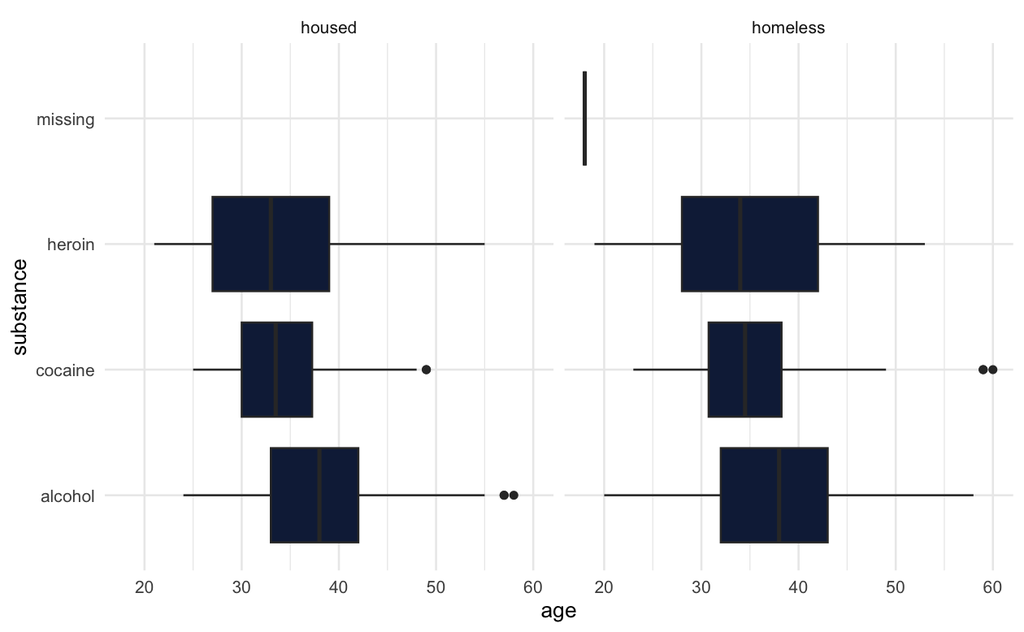

*Result* This graph shows the usages of each substance (alcohol, cocaine, and heroin) for each age and if these individuals are housed or homeless. The facets created to compare the primary susbtance used for each individual for those who are housed and those who are homeless.